# FInal

```python
import pandas as pd
import numpy as np
import matplotlib.pyplot as plt
import seaborn as sns
%matplotlib inline

# Load the dataset
print("Loading the dataset...")
df = pd.read_excel('Online Retail.xlsx')

# Basic information about the dataset
print(f"\nShape of the dataset: {df.shape}")
print("\nFirst 5 rows:")
print(df.head())

# Data types and missing values
print("\nData types and missing values:")
print(df.info())

# Statistical summary of numerical columns
print("\nStatistical summary:")
print(df.describe())

# Unique values in categorical columns
print("\nUnique values in Country column:")
print(df['Country'].nunique())
print(df['Country'].value_counts().head(10))
```

```
Loading the dataset...

Shape of the dataset: (541909, 8)

First 5 rows:
  InvoiceNo StockCode                          Description  Quantity  \
0    536365    85123A   WHITE HANGING HEART T-LIGHT HOLDER         6
1    536365     71053                  WHITE METAL LANTERN         6
2    536365    84406B       CREAM CUPID HEARTS COAT HANGER         8
3    536365    84029G  KNITTED UNION FLAG HOT WATER BOTTLE         6
4    536365    84029E       RED WOOLLY HOTTIE WHITE HEART.         6

          InvoiceDate  UnitPrice  CustomerID         Country
0 2010-12-01 08:26:00       2.55     17850.0  United Kingdom
1 2010-12-01 08:26:00       3.39     17850.0  United Kingdom
2 2010-12-01 08:26:00       2.75     17850.0  United Kingdom
3 2010-12-01 08:26:00       3.39     17850.0  United Kingdom
4 2010-12-01 08:26:00       3.39     17850.0  United Kingdom

Data types and missing values:
<class 'pandas.core.frame.DataFrame'>
RangeIndex: 541909 entries, 0 to 541908
Data columns (total 8 columns):
 #   Column       Non-Null Count   Dtype
---  ------       --------------   -----
 0   InvoiceNo    541909 non-null  object
 1   StockCode    541909 non-null  object
 2   Description  540455 non-null  object
 3   Quantity     541909 non-null  int64
 4   InvoiceDate  541909 non-null  datetime64[ns]
 5   UnitPrice    541909 non-null  float64
 6   CustomerID   406829 non-null  float64
 7   Country      541909 non-null  object
dtypes: datetime64[ns](1), float64(2), int64(1), object(4)
memory usage: 33.1+ MB
None

Statistical summary:
            Quantity                    InvoiceDate      UnitPrice  \
count  541909.000000                         541909  541909.000000
```

[output cut: 17 more lines]

```

Unique values in Country column:
38
Country
United Kingdom    495478
Germany             9495
France              8557
EIRE                8196
Spain               2533
Netherlands         2371
Belgium             2069
Switzerland         2002
Portugal            1519
Australia           1259
Name: count, dtype: int64
```

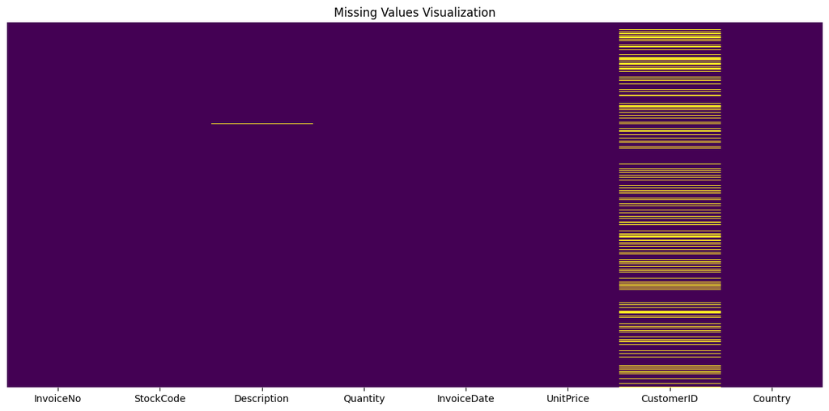

```
Extreme Quantity values:
540422   -80995
61624    -74215
225529    -9600
225530    -9600
4287      -9360
Name: Quantity, dtype: int64
421632     4800
74614      5568
502122    12540
61619     74215
540421    80995
Name: Quantity, dtype: int64

Extreme UnitPrice values:
299983   -11062.06
299984   -11062.06
116405        0.00
116921        0.00
116920        0.00
Name: UnitPrice, dtype: float64
15017     13541.33
43703     16453.71
43702     16888.02
524602    17836.46
222681    38970.00
Name: UnitPrice, dtype: float64
```

```
Number of potential return transactions: 9288
```

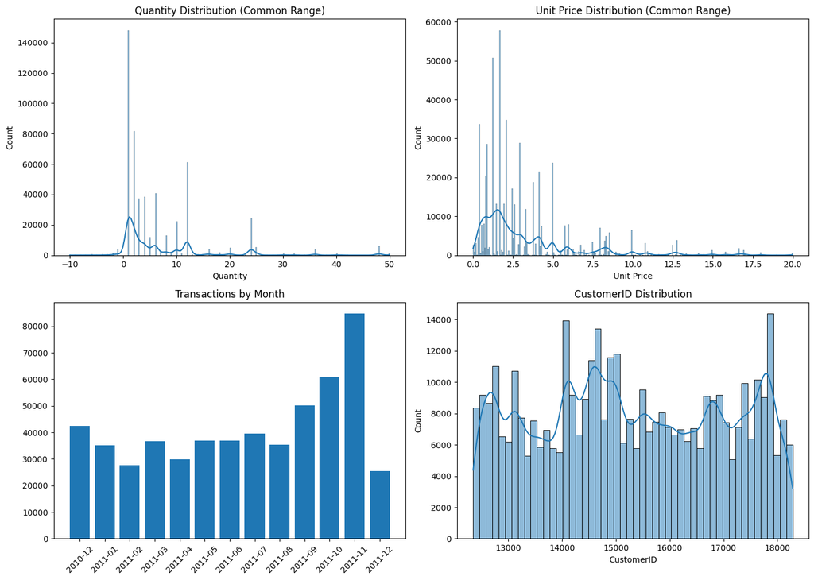

```python
# Create visualizations based on what we've observed
plt.figure(figsize=(12, 6))
sns.heatmap(df.isnull(), cbar=False, yticklabels=False, cmap='viridis')
plt.title('Missing Values Visualization')
plt.tight_layout()
plt.show()

# Analyze the distributions of key numerical columns
fig, axes = plt.subplots(2, 2, figsize=(14, 10))

# Quantity distribution (reasonable range)
sns.histplot(df[df['Quantity'].between(-10, 50)]['Quantity'], ax=axes[0, 0], kde=True)
axes[0, 0].set_title('Quantity Distribution (Common Range)')
axes[0, 0].set_xlabel('Quantity')

# Check extreme quantities
print("\nExtreme Quantity values:")
print(df['Quantity'].sort_values().head(5))  # Lowest quantities
print(df['Quantity'].sort_values().tail(5))  # Highest quantities

# UnitPrice distribution (reasonable range)
sns.histplot(df[df['UnitPrice'].between(0, 20)]['UnitPrice'], ax=axes[0, 1], kde=True)
axes[0, 1].set_title('Unit Price Distribution (Common Range)')
axes[0, 1].set_xlabel('Unit Price')

# Extreme unit prices
print("\nExtreme UnitPrice values:")
print(df['UnitPrice'].sort_values().head(5))  # Lowest prices
print(df['UnitPrice'].sort_values().tail(5))  # Highest prices

# Transactions over time
monthly_sales = df.groupby(df['InvoiceDate'].dt.to_period('M')).size()
monthly_sales.index = monthly_sales.index.astype(str)
axes[1, 0].bar(monthly_sales.index, monthly_sales.values)
axes[1, 0].set_title('Transactions by Month')
axes[1, 0].set_xticklabels(monthly_sales.index, rotation=45)

# Check for return transactions (invoices starting with 'C')
returns = df[df['InvoiceNo'].astype(str).str.startswith('C')]
print(f"\nNumber of potential return transactions: {len(returns)}")

# CustomerID distribution
sns.histplot(df['CustomerID'].dropna(), ax=axes[1, 1], kde=True, bins=50)
axes[1, 1].set_title('CustomerID Distribution')
axes[1, 1].set_xlabel('CustomerID')

plt.tight_layout()
plt.show()
```

```
Records after removing missing CustomerID: 406829

Handling return transactions:
Number of cancellation records: 8905
Number of unique customers with cancellations: 1589

Clean dataset statistics:
```

```
            Quantity      UnitPrice    TotalAmount
count  406829.000000  406829.000000  406829.000000
mean       12.061303       3.460471      20.401854
std       248.693370      69.315162     427.591718
min    -80995.000000       0.000000 -168469.600000
25%         2.000000       1.250000       4.200000
50%         5.000000       1.950000      11.100000
75%        12.000000       3.750000      19.500000
max     80995.000000   38970.000000  168469.600000
```

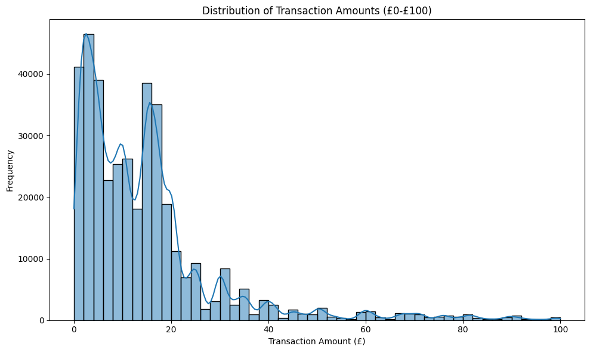

```python
# Step 1: Remove transactions with missing CustomerID as we need this for customer segmentation
df_clean = df.dropna(subset=['CustomerID'])
print(f"Records after removing missing CustomerID: {df_clean.shape[0]}")

# Step 2: Convert CustomerID to integer for easier handling
df_clean['CustomerID'] = df_clean['CustomerID'].astype(int)

# Step 3: Examine and handle return transactions
print("\nHandling return transactions:")
# Identify returns (C for cancellation in invoice number)
cancellations = df_clean[df_clean['InvoiceNo'].astype(str).str.startswith('C')]
print(f"Number of cancellation records: {len(cancellations)}")
print(f"Number of unique customers with cancellations: {cancellations['CustomerID'].nunique()}")

# Step 4: Calculate total amount per transaction
df_clean['TotalAmount'] = df_clean['Quantity'] * df_clean['UnitPrice']

# Step 5: Examine the clean dataset before feature engineering
print("\nClean dataset statistics:")
print(df_clean[['Quantity', 'UnitPrice', 'TotalAmount']].describe())

# Step 6: Let's visualize the distribution of total purchase amounts
plt.figure(figsize=(10, 6))
sns.histplot(df_clean[df_clean['TotalAmount'].between(0, 100)]['TotalAmount'], bins=50, kde=True)
plt.title('Distribution of Transaction Amounts (£0-£100)')
plt.xlabel('Transaction Amount (£)')
plt.ylabel('Frequency')
plt.tight_layout()
plt.show()
```

```
Last transaction date: 2011-12-09 12:50:00
Analysis date: 2011-12-10 12:50:00

RFM Metrics Summary:
         CustomerID      Recency    Frequency       Monetary  ReturnFrequency  \
count   4339.000000  4339.000000  4339.000000    4339.000000      4339.000000
mean   15299.936852    92.518322     4.271952    2053.793018         0.833833
std     1721.889758   100.009747     7.705493    8988.248381         2.145427
min    12346.000000     1.000000     1.000000       0.000000         0.000000
25%    13812.500000    18.000000     1.000000     307.245000         0.000000
50%    15299.000000    51.000000     2.000000     674.450000         0.000000
75%    16778.500000   142.000000     5.000000    1661.640000         1.000000
max    18287.000000   374.000000   210.000000  280206.020000        47.000000

        ReturnAmount  ReturnRatio
count    4339.000000  4339.000000
mean     -138.495241     0.039663
std      2962.849174     0.874756
min   -168469.600000     0.000000
25%       -15.900000     0.000000
50%         0.000000     0.000000
75%         0.000000     0.010792
max         0.000000    57.050667
```

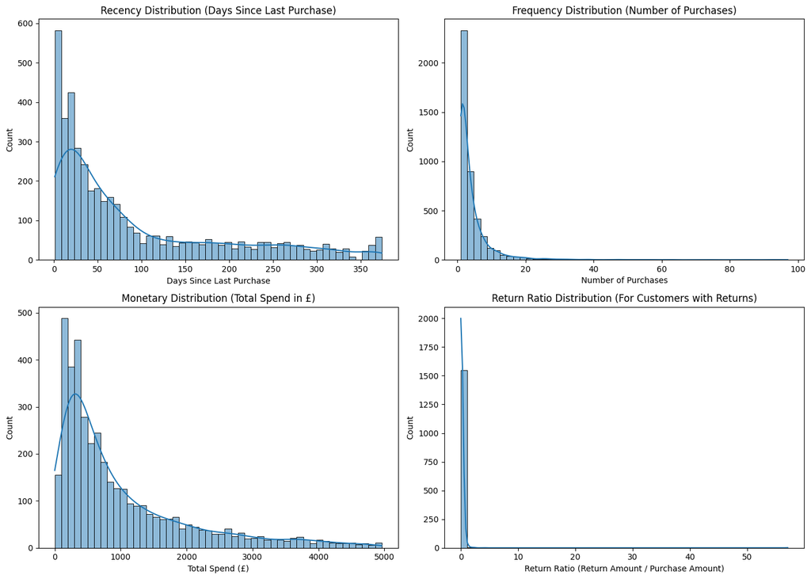

```python
# Create RFM features for customer segmentation
import datetime as dt

# Get the date of the last transaction in the dataset
last_date = df_clean['InvoiceDate'].max()
print(f"Last transaction date: {last_date}")

# Add one day to make sure all recency calculations are based on days *since* last purchase
analysis_date = last_date + dt.timedelta(days=1)
print(f"Analysis date: {analysis_date}")

# Group by CustomerID and create RFM metrics
# First, handle the returns (negative values) by focusing on successful purchases
df_pos = df_clean[df_clean['Quantity'] > 0]

# Create RFM dataframe
rfm = df_pos.groupby('CustomerID').agg({
    'InvoiceDate': lambda x: (analysis_date - x.max()).days,  # Recency
    'InvoiceNo': 'nunique',                                   # Frequency (unique invoices)
    'TotalAmount': 'sum'                                      # Monetary
}).reset_index()

# Rename columns
rfm.columns = ['CustomerID', 'Recency', 'Frequency', 'Monetary']

# Create a separate dataframe for returns information
returns_per_customer = df_clean[df_clean['Quantity'] < 0].groupby('CustomerID').agg({
    'InvoiceNo': 'nunique',       # Number of return transactions
    'TotalAmount': 'sum'          # Total return amount (will be negative)
}).reset_index()

returns_per_customer.columns = ['CustomerID', 'ReturnFrequency', 'ReturnAmount']

# Merge the returns information with the RFM dataframe
rfm = pd.merge(rfm, returns_per_customer, on='CustomerID', how='left')

# Fill NaN values in returns columns with 0 (customers with no returns)
rfm['ReturnFrequency'] = rfm['ReturnFrequency'].fillna(0)
rfm['ReturnAmount'] = rfm['ReturnAmount'].fillna(0)

# Calculate return ratio (interesting for segmentation)
rfm['ReturnRatio'] = rfm['ReturnAmount'].abs() / rfm['Monetary']
rfm['ReturnRatio'] = rfm['ReturnRatio'].fillna(0)

# Display summary statistics of RFM metrics
print("\nRFM Metrics Summary:")
print(rfm.describe())

# Visualize the distributions of RFM metrics
fig, axes = plt.subplots(2, 2, figsize=(14, 10))

# Recency distribution
sns.histplot(rfm['Recency'], bins=50, kde=True, ax=axes[0, 0])
axes[0, 0].set_title('Recency Distribution (Days Since Last Purchase)')
axes[0, 0].set_xlabel('Days Since Last Purchase')

# Frequency distribution
sns.histplot(rfm[rfm['Frequency'] < 100]['Frequency'], bins=50, kde=True, ax=axes[0, 1])
axes[0, 1].set_title('Frequency Distribution (Number of Purchases)')
axes[0, 1].set_xlabel('Number of Purchases')

# Monetary distribution
sns.histplot(rfm[rfm['Monetary'] < 5000]['Monetary'], bins=50, kde=True, ax=axes[1, 0])
axes[1, 0].set_title('Monetary Distribution (Total Spend in £)')
axes[1, 0].set_xlabel('Total Spend (£)')

# Return ratio distribution
sns.histplot(rfm[rfm['ReturnRatio'] > 0]['ReturnRatio'], bins=50, kde=True, ax=axes[1, 1])
axes[1, 1].set_title('Return Ratio Distribution (For Customers with Returns)')
axes[1, 1].set_xlabel('Return Ratio (Return Amount / Purchase Amount)')

plt.tight_layout()
plt.show()
```

```
Customers after filtering outliers: 4317 of 4339
```

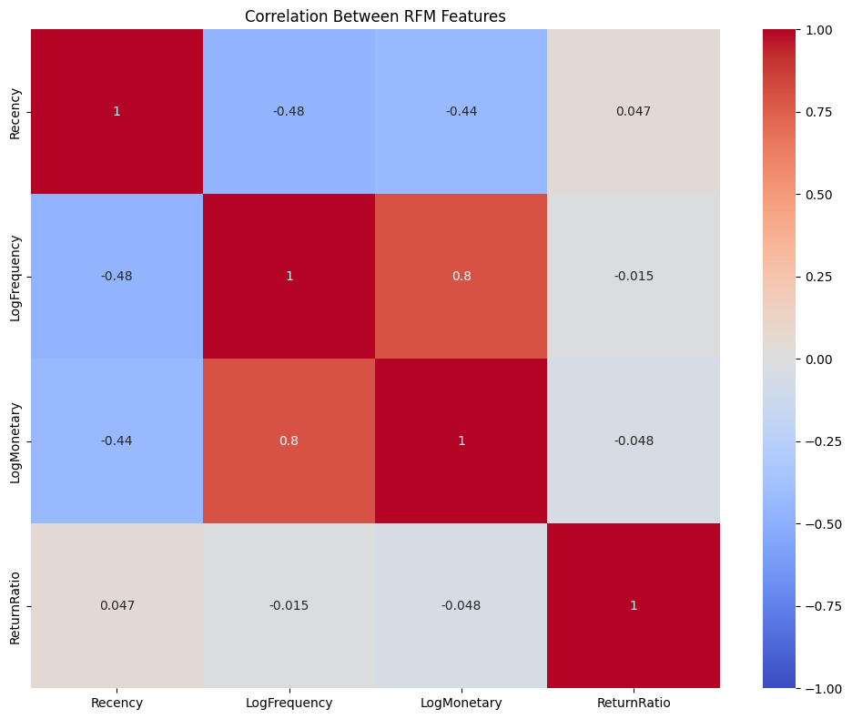

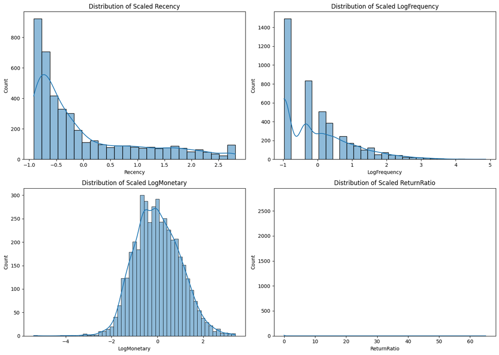

```python
# Step 1: Remove extreme outliers (keep customers with reasonable spending patterns)
rfm_filtered = rfm[(rfm['Monetary'] < 50000) & (rfm['Frequency'] < 100)]
print(f"Customers after filtering outliers: {len(rfm_filtered)} of {len(rfm)}")

# Step 2: Log-transform skewed distributions (Frequency and Monetary)
# Add 1 before log transform to handle zeros
rfm_filtered['LogFrequency'] = np.log1p(rfm_filtered['Frequency'])
rfm_filtered['LogMonetary'] = np.log1p(rfm_filtered['Monetary'])

# Step 3: Scale features for clustering
from sklearn.preprocessing import StandardScaler

# Select and scale features for clustering
features = ['Recency', 'LogFrequency', 'LogMonetary', 'ReturnRatio']
scaler = StandardScaler()
rfm_scaled = scaler.fit_transform(rfm_filtered[features])
rfm_scaled = pd.DataFrame(rfm_scaled, columns=features)

# Let's visualize the correlation between our features
plt.figure(figsize=(10, 8))
sns.heatmap(rfm_filtered[features].corr(), annot=True, cmap='coolwarm', vmin=-1, vmax=1)
plt.title('Correlation Between RFM Features')
plt.tight_layout()
plt.show()

# Let's also visualize the scaled features
fig, axes = plt.subplots(2, 2, figsize=(14, 10))
for i, feature in enumerate(features):
    row, col = i // 2, i % 2
    sns.histplot(rfm_scaled[feature], kde=True, ax=axes[row, col])
    axes[row, col].set_title(f'Distribution of Scaled {feature}')
plt.tight_layout()
plt.show()
```

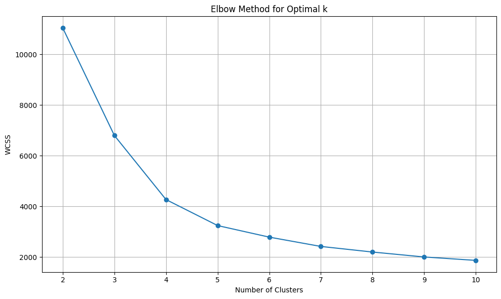

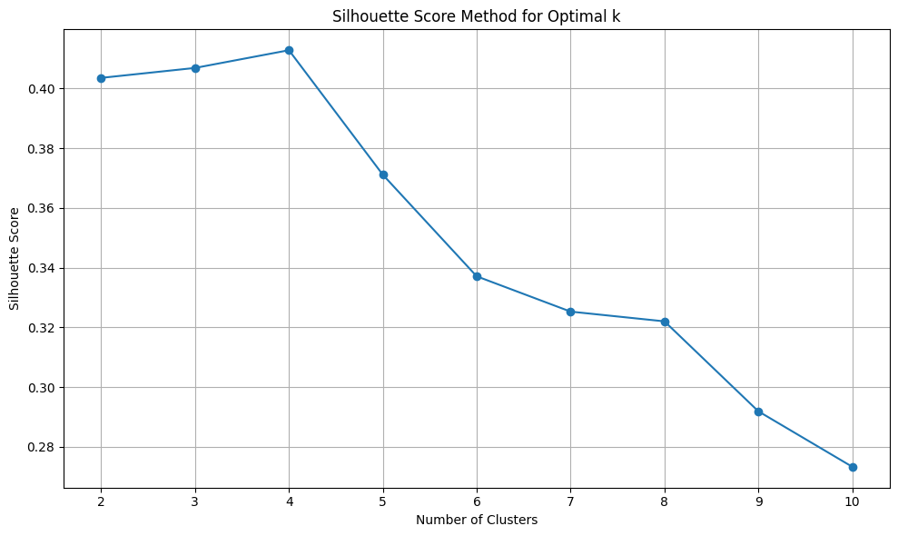

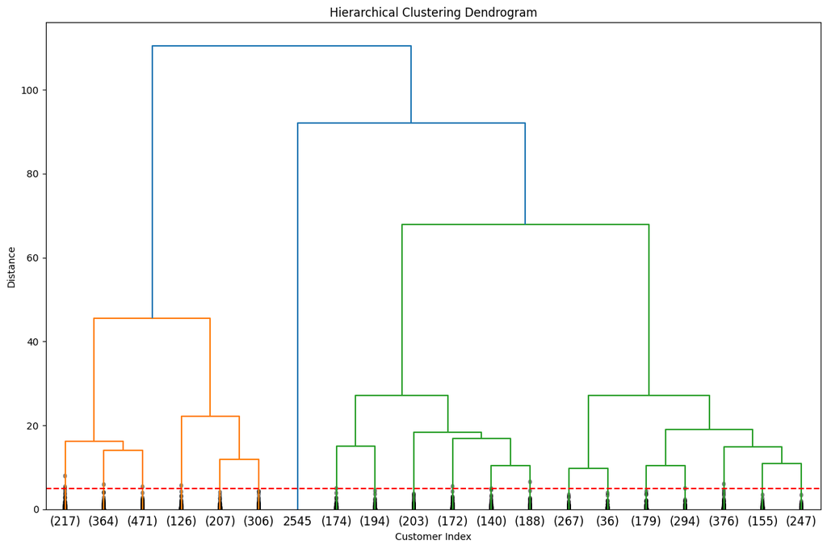

```python
from sklearn.cluster import KMeans
from scipy.cluster.hierarchy import dendrogram, linkage
from sklearn.metrics import silhouette_score
import matplotlib.cm as cm

# Step 1: Determine optimal number of clusters using the Elbow Method
wcss = []  # Within-cluster sum of squares
silhouette_scores = []
max_clusters = 10

for i in range(2, max_clusters+1):
    kmeans = KMeans(n_clusters=i, random_state=42, n_init=10)
    kmeans.fit(rfm_scaled)
    wcss.append(kmeans.inertia_)

    # Calculate silhouette score
    labels = kmeans.labels_
    silhouette_scores.append(silhouette_score(rfm_scaled, labels))

# Plot WCSS (Elbow Method)
plt.figure(figsize=(10, 6))
plt.plot(range(2, max_clusters+1), wcss, marker='o')
plt.title('Elbow Method for Optimal k')
plt.xlabel('Number of Clusters')
plt.ylabel('WCSS')
plt.grid(True)
plt.tight_layout()
plt.show()

# Plot Silhouette Scores
plt.figure(figsize=(10, 6))
plt.plot(range(2, max_clusters+1), silhouette_scores, marker='o')
plt.title('Silhouette Score Method for Optimal k')
plt.xlabel('Number of Clusters')
plt.ylabel('Silhouette Score')
plt.grid(True)
plt.tight_layout()
plt.show()

# Based on the results, let's also try hierarchical clustering visualization
# Generate linkage matrix
Z = linkage(rfm_scaled, method='ward')

# Plot dendrogram - with corrected parameters
plt.figure(figsize=(12, 8))
plt.title('Hierarchical Clustering Dendrogram')
plt.xlabel('Customer Index')
plt.ylabel('Distance')
dendrogram(Z, truncate_mode='lastp', p=20, show_contracted=True)
plt.axhline(y=5, color='r', linestyle='--')  # Add a horizontal line for reference
plt.tight_layout()
plt.show()
```

```
Number of customers in each cluster:
Cluster 0: 1992 customers (46.1%)
Cluster 1: 1350 customers (31.3%)
Cluster 2: 974 customers (22.6%)
Cluster 3: 1 customers (0.0%)

Cluster Summary:
         Recency (days)  Frequency (orders)  Monetary (£)  Avg Return Ratio  \
Cluster
0                 54.90                2.00        598.49              0.02
1                 31.45                8.78       3801.97              0.03
2                255.42                1.38        396.09              0.03
3                372.00                1.00         15.00             57.05

         % with Returns  Count
Cluster
0                 22.19   1992
1                 66.15   1350
2                 20.33    974
3                100.00      1
```

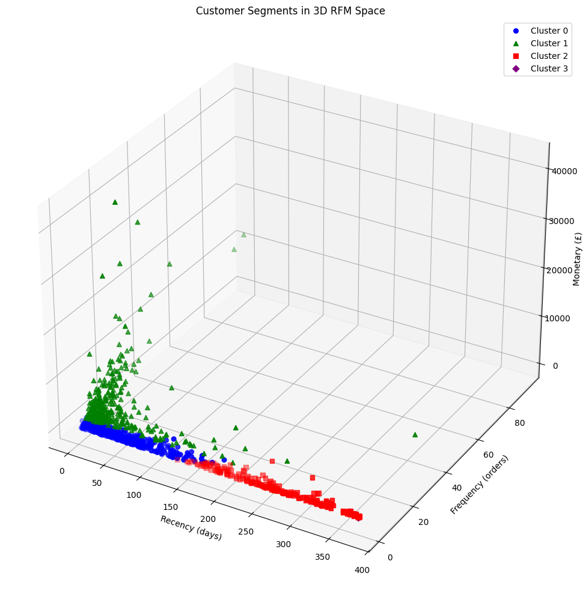

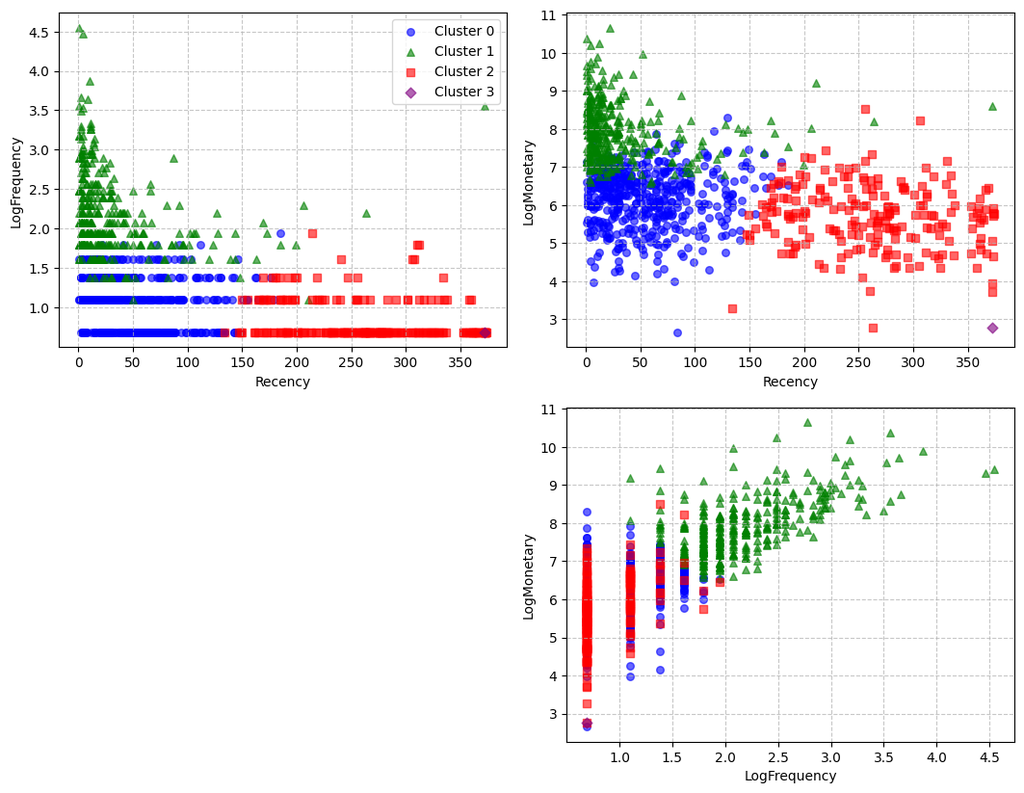

```python
# Implement K-means with k=4
kmeans = KMeans(n_clusters=4, random_state=42, n_init=10)
rfm_filtered['Cluster'] = kmeans.fit_predict(rfm_scaled)

# Get cluster centers
cluster_centers = pd.DataFrame(scaler.inverse_transform(kmeans.cluster_centers_),
                              columns=features)

# Count customers in each cluster
cluster_counts = rfm_filtered['Cluster'].value_counts().sort_index()
print("Number of customers in each cluster:")
for cluster, count in cluster_counts.items():
    print(f"Cluster {cluster}: {count} customers ({count/len(rfm_filtered)*100:.1f}%)")

# Calculate average RFM values for each cluster
cluster_summary = rfm_filtered.groupby('Cluster').agg({
    'Recency': 'mean',
    'Frequency': 'mean',
    'Monetary': 'mean',
    'ReturnRatio': ['mean', lambda x: (x > 0).mean() * 100],  # Mean and % with returns
    'CustomerID': 'count'
}).round(2)

# Rename columns for better readability
cluster_summary.columns = ['Recency (days)', 'Frequency (orders)', 'Monetary (£)',
                          'Avg Return Ratio', '% with Returns', 'Count']
print("\nCluster Summary:")
print(cluster_summary)

# Visualize the clusters
# Create a 3D scatter plot for Recency, Frequency, and Monetary with color by cluster
from mpl_toolkits.mplot3d import Axes3D

fig = plt.figure(figsize=(12, 10))
ax = fig.add_subplot(111, projection='3d')

colors = ['blue', 'green', 'red', 'purple']
markers = ['o', '^', 's', 'D']

# Sample a subset of points to make the plot clearer
sample_size = min(1000, len(rfm_filtered))
rfm_sample = rfm_filtered.sample(sample_size, random_state=42)

for cluster in range(4):
    cluster_data = rfm_sample[rfm_sample['Cluster'] == cluster]
    ax.scatter(
        cluster_data['Recency'],
        cluster_data['Frequency'],
        cluster_data['Monetary'],
        s=30,
        c=colors[cluster],
        marker=markers[cluster],
        label=f'Cluster {cluster}'
    )

ax.set_xlabel('Recency (days)')
ax.set_ylabel('Frequency (orders)')
ax.set_zlabel('Monetary (£)')
ax.set_title('Customer Segments in 3D RFM Space')
ax.legend()
plt.tight_layout()
plt.show()

# 2D visualization with pair plots
plt.figure(figsize=(16, 12))
for i, feature1 in enumerate(features[:3]):  # Exclude ReturnRatio for clarity
    for j, feature2 in enumerate(features[:3]):
        if i >= j:  # Skip duplicate and same-feature plots
            continue

        plt.subplot(3, 3, (i*3 + j))
        for cluster in range(4):
            cluster_data = rfm_sample[rfm_sample['Cluster'] == cluster]
            plt.scatter(
                cluster_data[feature1],
                cluster_data[feature2],
                s=30,
                c=colors[cluster],
                marker=markers[cluster],
                alpha=0.6,
                label=f'Cluster {cluster}' if i == 0 and j == 1 else ""
            )
        plt.xlabel(feature1)
        plt.ylabel(feature2)
        plt.grid(True, linestyle='--', alpha=0.7)

        if i == 0 and j == 1:
            plt.legend()

plt.tight_layout()
plt.show()
```

Customer Segment Analysis Cluster 1: High-Value Loyal Customers (31.3%)

Characteristics:

Most recent purchases (31 days) Highest purchase frequency (8.8 orders) Highest spending (£3,802 average) 66% have made returns (indicates engagement with the brand)

Segment Description: These are your VIP customers - they shop frequently, spend significantly, and have made purchases recently. Their high return rate actually indicates engagement rather than dissatisfaction.

Cluster 0: Occasional Medium-Value Customers (46.1%)

Characteristics:

Moderately recent (55 days since last purchase) Low purchase frequency (2 orders) Medium spending (£598 average) Only 22% have made returns

Segment Description: These represent your average customers who shop occasionally but aren't deeply engaged with the brand. They're active but not committed.

Cluster 2: At-Risk/Churned Customers (22.6%)

Characteristics:

Very low recency (255 days since last purchase) Lowest frequency (1.4 orders) Lower spending (£396 average) 20% have made returns

Segment Description: These customers haven't shopped in a long time and are likely churned or at high risk of churning. They made few purchases before disappearing.

Cluster 3: Outlier (1 customer)

A single customer with extremely high return ratio (57) and very low activity.

Marketing Strategy Recommendations For High-Value Loyal Customers (Cluster 1):

Loyalty Program: Implement premium rewards for these top spenders Exclusive Access: Early access to new products and collections Personalized Recommendations: Based on their extensive purchase history Premium Customer Service: Dedicated support channels Referral Incentives: Reward them for bringing similar high-value customers

For Occasional Medium-Value Customers (Cluster 0):

Frequency Boosters: Incentives to shop more often (e.g., "Buy 3 get 1 free") Cross-Selling Campaigns: Recommend complementary products Engagement Content: More regular newsletters and product spotlights Mid-tier Loyalty Benefits: Encourage more consistent purchasing Special Occasion Promotions: Birthday offers, seasonal specials

For At-Risk/Churned Customers (Cluster 2):

Win-Back Campaigns: "We miss you" emails with significant discounts Feedback Surveys: Understand why they stopped purchasing Product Updates: Highlight what's new since their last purchase Last-Chance Offers: Time-limited significant discounts Remarketing Ads: Target them with visual reminders of your brand

Expected Business Impact By implementing these targeted strategies based on customer segmentation:

Increased Revenue: More personalized approaches should boost conversion rates Improved Retention: Better addressing the needs of each segment Reduced Marketing Waste: More efficient allocation of marketing resources Better Customer Experience: More relevant communications and offers Higher Customer Lifetime Value: Extending relationships through proper nurturing

Would you like me to elaborate on any specific segment or strategy recommendation? Or should we proceed to implementing the clustering model and evaluating its effectiveness?